# 5. praktikum

### Tulpdiagramm

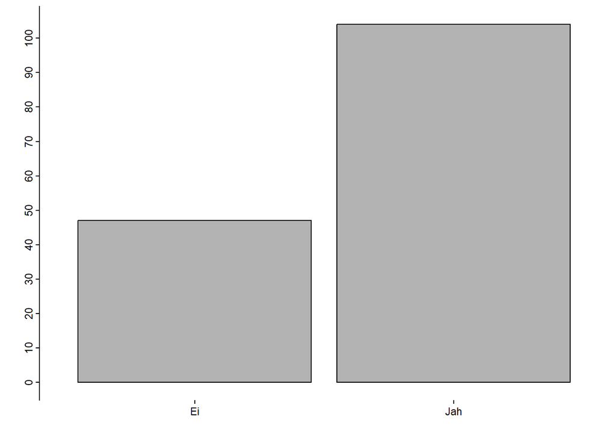

```r
# Tulpdiagramm kvantitatiivsete meetoditega töötamise kogemusest
ggplot(kysimustik,
       aes(x = kogemused_kvant)) +
  geom_bar(fill = "grey70",
           color = "black") +
  labs(y = "", x = "") +
  scale_y_continuous(breaks = seq(0, 100, 10)) +
  theme_classic() +
  theme(axis.line.x = element_blank(), # kustuta x-telje joon
        axis.text.y = element_text(angle = 90, # y-telje tekst 90-kraadise kaldega
                                   hjust = 0.5)) # y-telje tekst joondatud sakkidega
```

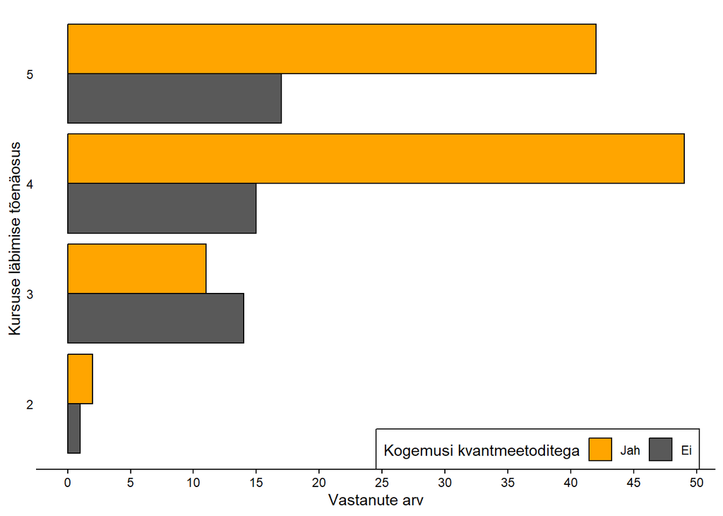

```r
# Horisontaalne tulpdiagramm
ggplot(kysimustik,
       aes(x = kursuse_labimine,
           fill = kogemused_kvant)) +
  geom_bar(position = "dodge", # kategooriad kõrvuti tulpadena
           color = "black") + # tulpade piirjoon must
  scale_x_discrete(drop = FALSE) + # jäta alles vastusteta kategooriad
  scale_y_continuous(breaks = seq(0, 100, 5)) + # y-teljel väärtused 0st 100ni viiese sammuga
  scale_fill_manual(values = c("grey35", "orange"), # määra käsitsi kogemused_kvant kategooriate värvid
                    name = "Kogemusi kvantmeetoditega") + # nimeta legend ümber
  labs(x = "Kursuse läbimise tõenäosus",
       y = "Vastanute arv") +
  theme_classic() +
  theme(axis.line.y = element_blank(), # kustuta ära y-telje joon
        axis.ticks.y = element_blank(), # kustuta ära y-telje sakid
        legend.position = c(0.5, 0), # legendi suhteline asend x- ja y-telje suhtes
        legend.justification = c(0,0), # legendi asetus
        legend.direction = "horizontal", # legend horisontaalne
        legend.background = element_rect(color = "black")) + # legendile must piirjoon ümber
  coord_flip() + # vaheta x- ja y-telg ära
  guides(fill = guide_legend(reverse = T)) # pööra legendi kategooriate järjekorda
```

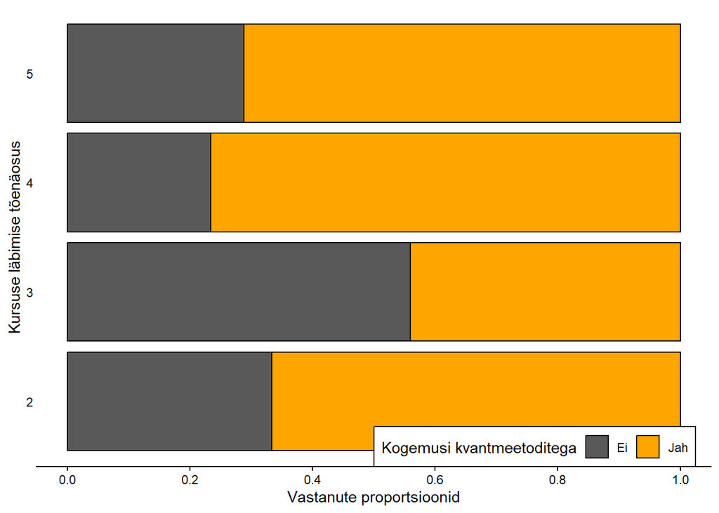

```r
# Horisontaalne tulpdiagramm osakaaludega
ggplot(kysimustik,
       aes(x = kursuse_labimine,
           fill = kogemused_kvant)) +
  geom_bar(position = position_fill(reverse = TRUE), # absoluutsageduste asemel osakaalud (skaala 0-1), nii et hall "Ei" osa oleks vasakul (vrd lihtsalt position = "fill")
           color = "black") +
  scale_x_discrete(drop = FALSE) + # näita ka vastusteta kategooriaid
  scale_y_continuous(breaks = seq(0, 1, 0.2)) + # y-skaala 0st 1ni intervalliga 0.2
  scale_fill_manual(values = c("grey35", "orange"),
                    name = "Kogemusi kvantmeetoditega") +
  labs(x = "Kursuse läbimise tõenäosus",
       y = "Vastanute proportsioonid") +
  theme_classic() +
  theme(axis.line.y = element_blank(), # kustuta y-telje joon
        axis.ticks.y = element_blank(), # kustuta y-telje sakid
        legend.position = c(0.5, 0),
        legend.justification = c(0,0),
        legend.direction = "horizontal",
        legend.background = element_rect(color = "black")) +
  coord_flip()
```

## Baasgraafika või ggplot2?

Kumbki graafikapakett ei ole olemuslikult parem kui teine ja on suur tõenäosus, et joonist, mida saad teha ggplotis, saad teha ka baasgraafikas (või hoopis mingi muu graafikapaketiga, nt `lattice`). Kummaga täpselt töötada, sõltub isiklikest eelistustest, harjumusest ja veidi ka sellest, milliseid graafikuid ja mille jaoks tüüpiliselt kasutatakse. Baasgraafikapaketiga saab enamasti kiiremini oma andmetest ülevaate, ggplot pakub veidi enam võimalusi nt rakendustes või veebilehtedel jooksvateks joonisteks ning on laialtlevinud andmeteaduses. Publitseerimiseks tuleb mõlema paketiga töötades joonistega pisut vaeva näha. Mõlemal paketil on ka terve hulk laiendusi, mis võimaldavad teha asju, millega pakett ise toime ei tule (nt 3D graafikud ggplotis). Asjad, milles ggplotil on siiski selge eelis, on nt legendid, grupeerimine ja paneelid (*facets*). Loe ka [siit](http://varianceexplained.org/r/why-I-use-ggplot2/).

## Ggploti lisamaterjale ja laiendusi

Väga põhjaliku ülevaate ggplotist ja selle laiendustest leiab nt lehelt https://github.com/erikgahner/awesome-ggplot2.

Sobiva joonisetüübi valimisel on kindlasti abiks aga leht https://www.data-to-viz.com/ ja juba mainitud https://r-charts.com/.

## Interaktiivsed graafikud ja plotly

Paketis `plotly` on funktsioon `ggplotly()`, mis võimaldab teha interaktiivseid graafikuid.

```r
# install.packages("plotly")
library(plotly)
```

```r
# Teeme esmalt tavalise ggploti graafiku ja salvestame selle mingisse objekti, nt nimega 'graafik1'
ggplot() +
  geom_bar(data = valimised, aes(x = sugu)) +
  geom_line(data = valimised, aes(x = sugu, group = nimekiri, color = nimekiri),
            stat = "count") -> graafik1

# Paneme tehtud graafikuobjekti funktsiooni ggplotly() sisse
# toolip-argumendis saame täpsustada, milliseid graafiku elemente hiirega joonisel liikudes näeb
ggplotly(graafik1, tooltip = c("y", "colour"))
```

[interactive chart not shown]

```r
ggplot(kysimustik, aes(x = synniaasta, y = kaua_opid, color = kogemused_kvant)) +
  geom_point() +
  scale_color_manual(values = c("grey45", "orange")) +
  labs(title = "Õpitud aastate arv vastavalt sünniaastale", subtitle = "ja kokkupuutele kvantitatiivsete meetoditega", x = "Sünniaasta", y = "Õpitud aastate arv", color = "Kogemused\nkvantitatiivsete\nmeetoditega") +
  theme(plot.title = element_text(hjust = 0.5),
        plot.subtitle = element_text(hjust = 0.5),
        panel.background = element_rect(fill = "aliceblue")) -> graafik2

ggplotly(graafik2, tooltip = "all")
```

[interactive chart not shown]

## Värvid ja värvipaletid

`ggplot2` võimaldab graafikuid värvida kas andmetest sõltuvalt või sõltumatult. Kui värv sõltub andmetest, täpsustavad seda argumendid `col` ja `fill` funktsioonis `aes()`. Sellisel juhul on võimalik värviskaalat muuta `scale`-funktsioonis.

```r
ggplot(data = kysimustik,
       aes(x = lemmikjook, fill = lemmikloom)) +
  geom_bar() +
  scale_fill_manual(values = c("yellow", "green", "blue", "red"))
```

```r
ggplot(data = kysimustik,
       aes(x = lemmikjook, fill = lemmikjook)) +
  geom_bar() +
  scale_fill_manual(values = c("black", "brown"))
```

Kui tulpade värv ei sõltu andmestikust, siis saab kasutada argumente `col` ja `fill` väljaspool funktsiooni `aes()`.

```r
ggplot(data = kysimustik,
       aes(x = lemmikjook)) +
  geom_bar(fill = c("black", "brown"))
```

R-is on võimalik kasutada väga erinevaid olemasolevaid värvipalette või panna kokku täiesti uus, endale meelepärane palett.

Erinevaid värvide nimetusi, mida on võimalik vaikimisi laaditava graafikapaketiga kasutada, saab vaadata RStudios funktsiooniga `colors()`.

```r
colors()
colors()[1:10] # esimesed 10 värvi
sample(colors(), 10) # suvalised 10 värvi
colors()[!grepl("grey", colors())] # värvid ilma hallideta
sample(colors()[!grepl("grey", colors())], 10) # suvalised 10 värvi ilma hallideta
```

Aga millised need värvid välja näevad? Võid vaadata näiteks sellelt lehelt siit või laadides hulga funktsioone käsuga `demo(colors())`.

```r
demo(colors())
```

Samuti näeb värve hõlpsalt, kui kasutada käsku

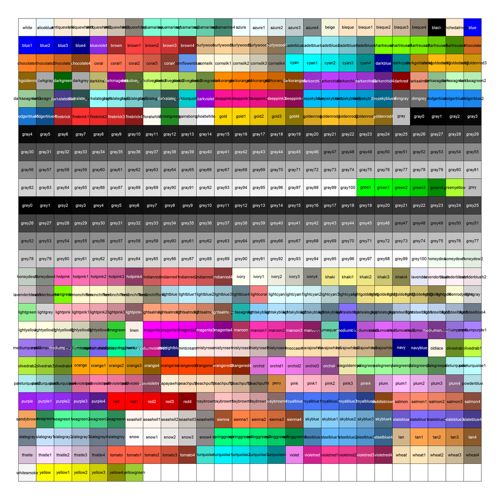

```r
scales::show_col(colors(), cex_label = 1)
```

Lisaks konkreetsetele nimetustele saab kasutada ka RGB-värvimudelit.

> Kõik värvid on võimalik kokku segada kolmest põhivärvist: punane, roheline ja sinine. Digitaalseadmetel töötab RGB-värvimudel (R - *red*, G - *green*, B - *blue*), trükkimiseks kasutatakse CMYK-mudelit (C - *cyan*, M - *magenta*, Y - *yellow*, K - *key*). Kõiki värvispektri värve saab tekitada graafiliselt punase, rohelise ja sinise värvi intensiivsuse muutmisel.

```r
col2rgb("white")
col2rgb("black")
col2rgb("green")
col2rgb("seagreen1")
col2rgb("forestgreen")
```

Samuti saab kasutada hex-värvikoode, mis koosnevad trellidest ja kuuest [kuueteistkümnendsüsteemis](https://et.wikipedia.org/wiki/Kuueteistk%C3%BCmnendarv) sümbolist. Hex-värvikoodid põhinevad kümnendarvudega väljendatud RGB-mudeli väärtuste teisendamisel kuueteistkümnendsüsteemi.

```r
# Sisend kümnendsüsteemis,
# väljund kuueteistkümnendsüsteemis
rgb(255,255,255,maxColorValue = 255) # white
rgb(0,0,0,maxColorValue = 255) # black
rgb(0,255,0,maxColorValue = 255) # green
rgb(84,255,159,maxColorValue = 255) # seagreen1
rgb(34,139,34,maxColorValue = 255) # forestgreen
```

Hex-värve saab kombineerida värvipaletiks lugematul hulgal veebilehtedel, nt lehel [Coolors](https://coolors.co/). Oma värvipaletti saab seejärel R-is mingil joonisel kasutada.

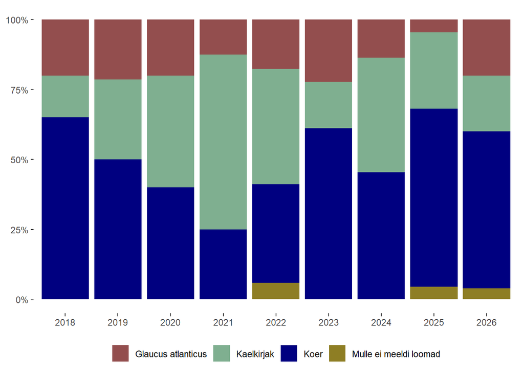

```r
# Erinevad viisid värvide täpsustamiseks
minupalett <- c(rgb(147,78,78,maxColorValue = 255), # punakaspruun
                "#7faf90", # tuhmroheline
                "navyblue", # tumesinine
                "#8e7e24") # tumekollane

ggplot(data = kysimustik,
       aes(x = aasta, fill = lemmikloom)) +
  geom_bar(position = "fill") + # absoluutarvude asemel osakaalud
  scale_fill_manual(values = minupalett) + # värvid
  scale_y_continuous(labels = scales::percent) + # y-teljel osakaalud näidatud protsentidena
  theme(panel.background = element_blank(), # kustuta joonise taust
        axis.title = element_blank(), # kustuta telgede nimed
        legend.position = "bottom", # aseta legend joonise alla
        legend.title = element_blank()) # kustuta legendi pealkiri
```

Alati ei pea aga ise värvipalette kokku panema, sest sellega võib kulutada väga palju aega ning lõpptulemus ei pruugi sellest paraneda. Seepärast on võimalik kasutada ka mitmeid valmis värvipalette erinevatest pakettidest.

### Baasgraafika paletid

Baasgraafika paketist saab erinevaid palette funktsioonidega `rainbow()`, `heat.colors()`, `terrain.colors()`, `topo.colors()` ja `cm.colors()`.

[figure not shown]

```r
# Funktsioonis saab täpsustada
# väljastatavate värvikoodide arvu
rainbow(10)
heat.colors(10)
terrain.colors(6)
topo.colors(7)
cm.colors(4)
```

### `RColorBrewer`

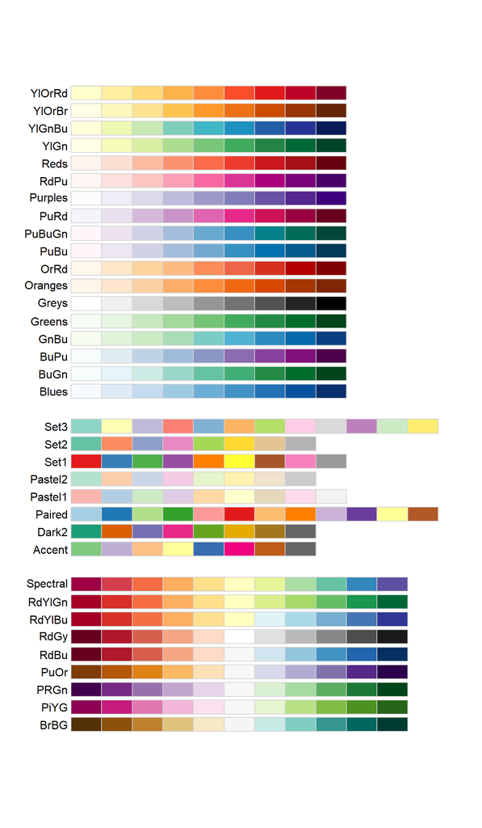

```r
# install.packages("RColorBrewer")
library(RColorBrewer)
display.brewer.all() # valmis paletid
```

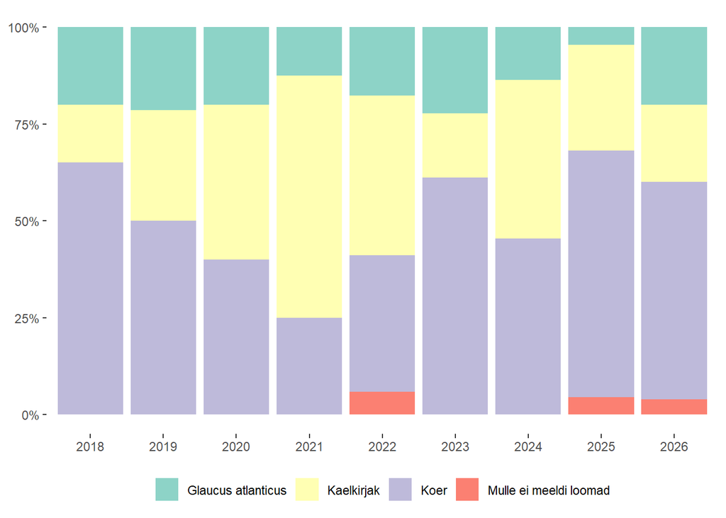

```r
ggplot(data = kysimustik,
       aes(x = aasta,
           fill = lemmikloom)) +
  geom_bar(position = "fill") +
  scale_fill_manual(values = brewer.pal(4,"Set3")) + # määra loomade värvideks käsitsi Breweri "Set3" paletist 4 esimest värvi
  scale_y_continuous(labels = scales::percent) +
  theme(panel.background = element_blank(),
        axis.title = element_blank(),
        legend.position = "bottom",
        legend.title = element_blank())
```

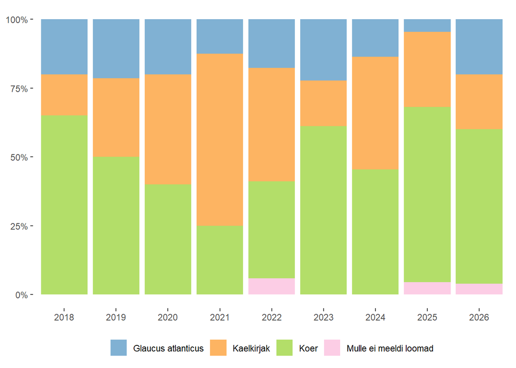

```r
ggplot(data = kysimustik,
       aes(x = aasta, fill = lemmikloom)) +
  geom_bar(position = "fill") +
  scale_fill_manual(values = brewer.pal(12, "Set3")[5:8]) + # määra loomade värvideks käsitsi Breweri "Set3" paleti 12 värvist värvid 5-8
  scale_y_continuous(labels = scales::percent) +
  theme(panel.background = element_blank(),
        axis.title = element_blank(),
        legend.position = "bottom",
        legend.title = element_blank())
```

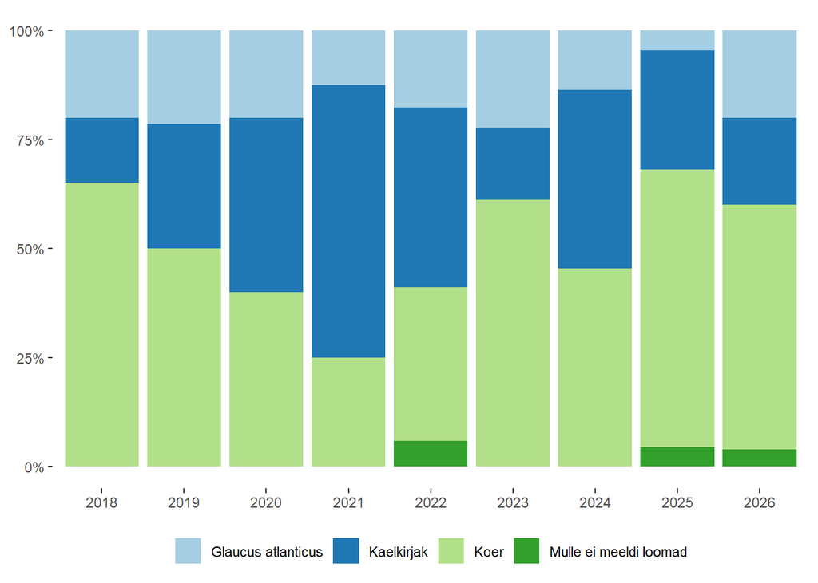

```r
ggplot(data = kysimustik,
       aes(x = aasta, fill = lemmikloom)) +
  geom_bar(position = "fill") +
  scale_fill_brewer(type = "qual", palette = 3) + # kasuta ggploti spetsiaalset breweri 'scale'-funktsiooni
  scale_y_continuous(labels = scales::percent) +
  theme(panel.background = element_blank(),
        axis.title = element_blank(),
        legend.position = "bottom",
        legend.title = element_blank())
```

### `colorspace`

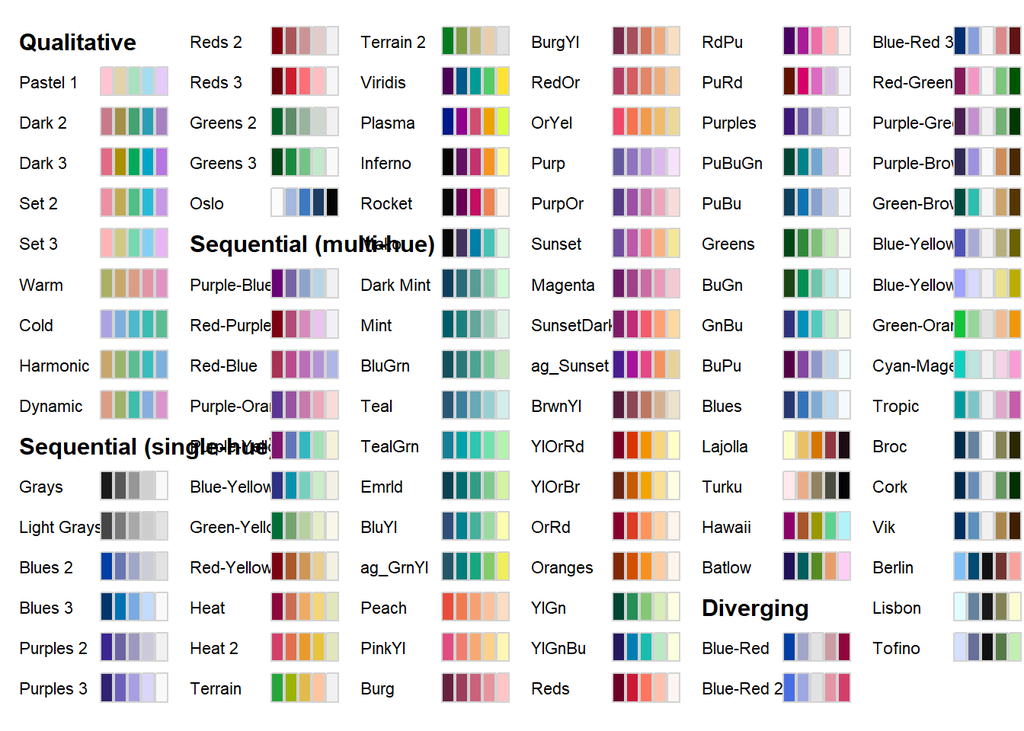

```r
# install.packages("colorspace")
library(colorspace)
hcl_palettes(plot = TRUE) # valmis paletid
```

```r
# väljasta täpsustatud paletist mingi arv hex-värvikoode
sequential_hcl(6, palette = "Red-Yellow")
qualitative_hcl(4, palette = "Dynamic")
diverging_hcl(10, palette = "Cork")
```

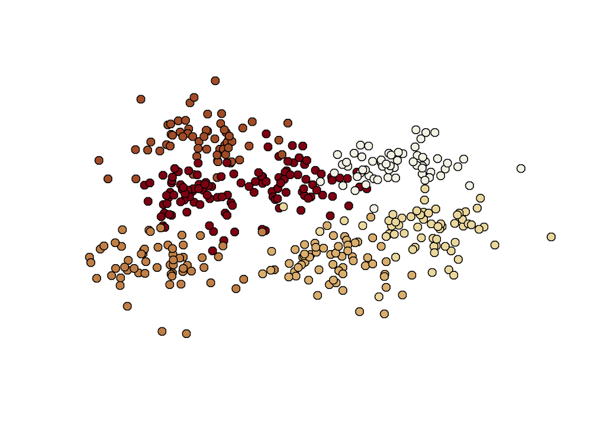

```r
# Kuidas näeksid need värvid eri tüüpi graafikutel välja?
demoplot(sequential_hcl(6, palette = "Red-Yellow"), type = "scatter")
```

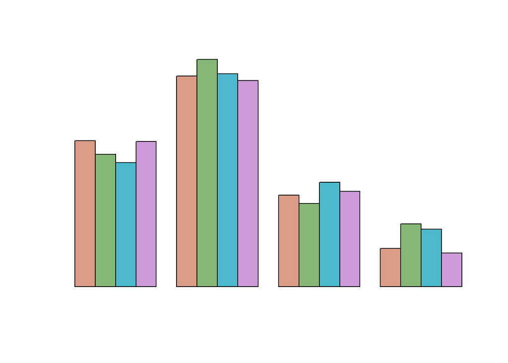

```r
demoplot(qualitative_hcl(4, palette = "Dynamic"), type = "bar")
```

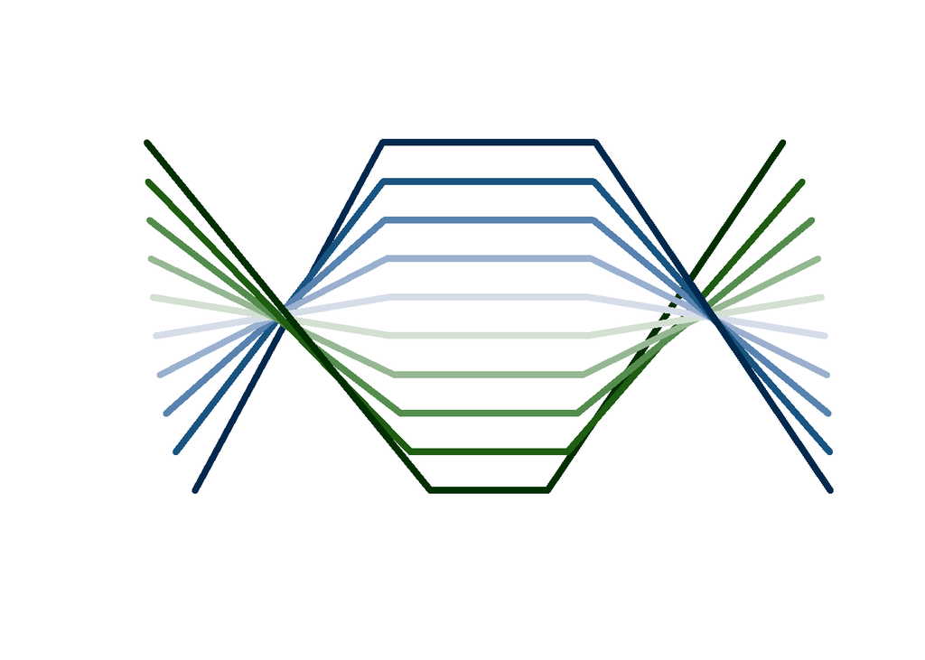

```r
demoplot(diverging_hcl(10, palette = "Cork"), type = "lines")
```

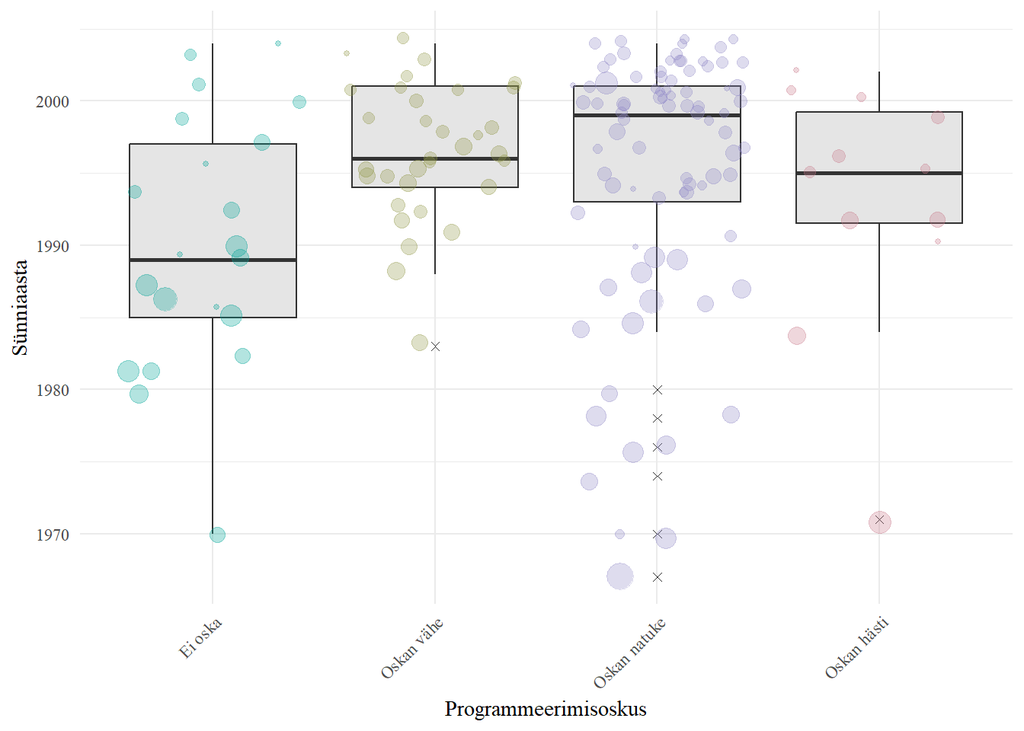

```r
# Programmeerimisoskuse ja sünniaasta suhet
# väljendavad karpdiagrammid,
# kuhu on hajutatult lisatud individuaalsed vaatlused.
# Individuaalsete vaatluste
# värv grupeerib erineva programmeerimisoskusega vastajaid,
# suurus aga viitab ülikoolis õpitud aastate arvule
# (mida suurem täpp, seda kauem õppinud).
ggplot(data = kysimustik,
       aes(x = programmeerimisoskus, y = synniaasta)) +
  geom_boxplot(fill = "grey90", # karpide värv
               outlier.shape = 4) + # erindite kuju
  geom_jitter(aes(size = kaua_opid, # suurus andmetest
                 color = programmeerimisoskus), # värv andmetest
             alpha = 0.3, # läbipaistvus
             show.legend = FALSE) + # ära näita legendi
  scale_x_discrete(limits = levels(kysimustik$programmeerimisoskus)[c(3,2,4,1)], # järjesta tasemed joonisel ümber
                   labels = c("Ei oska", "Oskan vähe",
                              "Oskan natuke", "Oskan hästi")) + # muuda joonisel silte
  scale_color_discrete_qualitative("Dark2") + # punktide värvipalett ggploti colorspace'i funktsioonist (diskreetsetele kvalitatiivsetele tunnustele)
  labs(x = "Programmeerimisoskus",
       y = "Sünniaasta") +
  theme_minimal() +
  theme(axis.text.x = element_text(angle = 45, # x-telje teksti kaldenurk
                                   hjust = 1), # x-telje teksti joondus
        text = element_text(family = "serif")) # muuda fonti
```

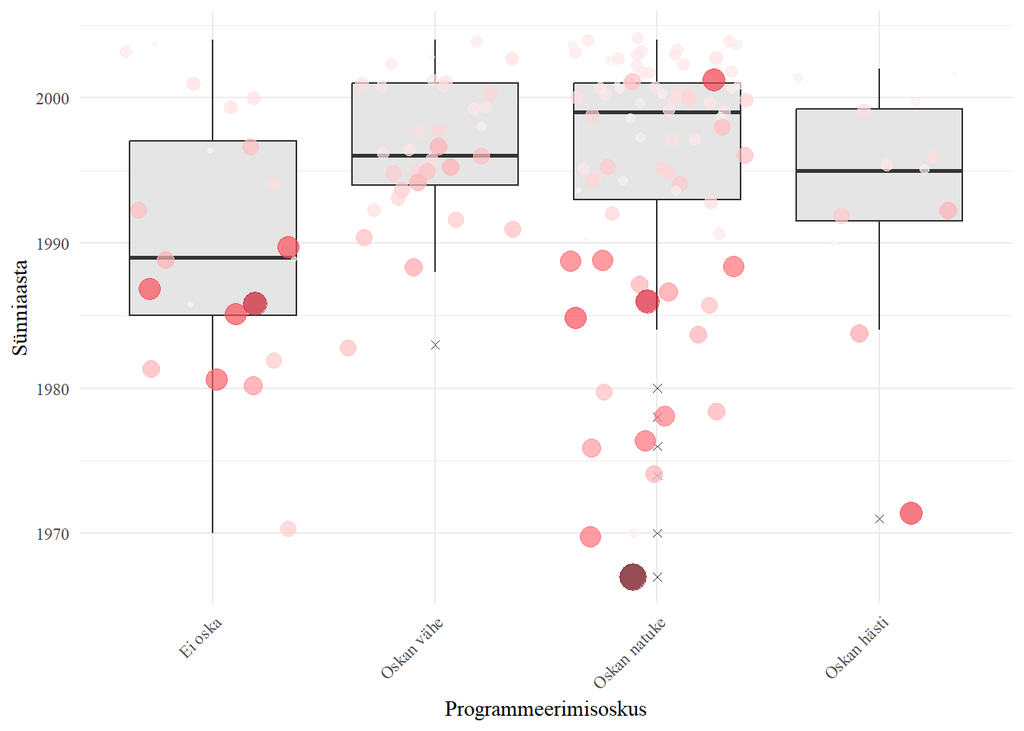

```r
# Programmeerimisoskuse ja sünniaasta suhet
# väljendavad karpdiagrammid,
# kuhu on hajutatult lisatud individuaalsed vaatlused.
# Nii individuaalsete vaatluste värv kui ka suurus
# viitavad ülikoolis õpitud aastate arvule.
ggplot(data = kysimustik,
       aes(x = programmeerimisoskus, y = synniaasta)) +
  geom_boxplot(fill = "grey90",
               outlier.shape = 4) +
  geom_jitter(aes(size = kaua_opid,
                 color = kaua_opid), # värv andmetest
             alpha = 0.7,
             show.legend = FALSE) +
  scale_x_discrete(limits = levels(kysimustik$programmeerimisoskus)[c(3,2,4,1)],
                   labels = c("Ei oska", "Oskan vähe",
                              "Oskan natuke", "Oskan hästi")) +
  scale_color_continuous_sequential("Reds3") + # punktide värvipalett ggploti colorspace'i funktsioonist (pidevatele  tunnustele)
  labs(x = "Programmeerimisoskus",
       y = "Sünniaasta") +
  theme_minimal() +
  theme(axis.text.x = element_text(angle = 45,
                                   hjust = 1),
        text = element_text(family = "serif")) # muuda fonti
```

## Järgmisel korral

Pakett `tidyverse` andmete töötlemiseks.